# Summarizing Data: Graphical Displays via ggplot2

## `ggplot2` side-by-side barplots

- **Side-by-side barplot** created by via `position` aesthetic
  - `dodge` for side-by-side bar plot
  - `jitter` for continuous data with many points at same values
  - `fill` stacks bars and standardises each stack to have constant height
  - `stack` stacks bars on top of each other

## `ggplot2` side-by-side barplots

- **Side-by-side barplot** created by via `position` aesthetic

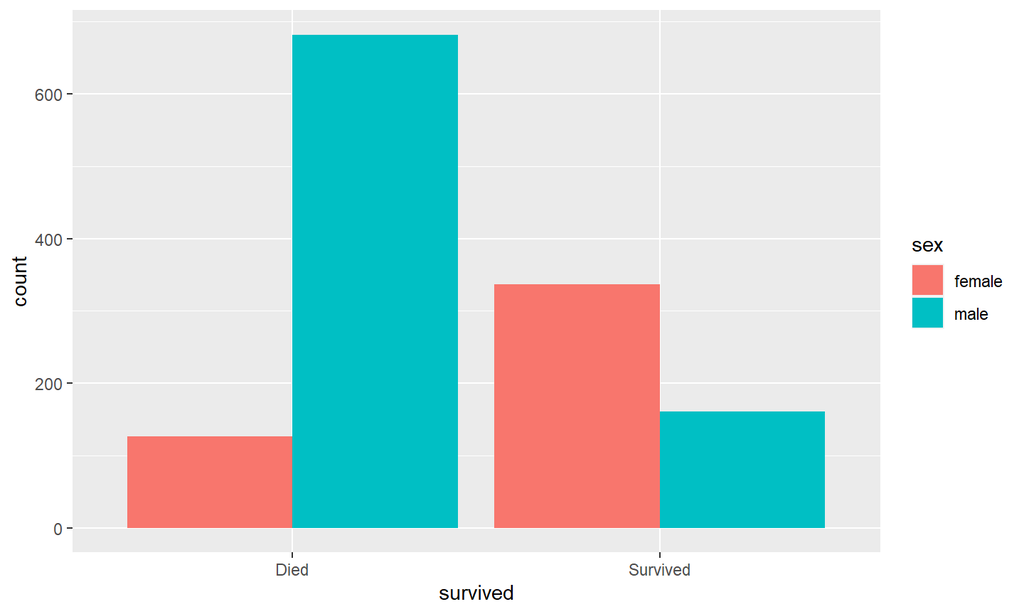

```r
ggplot(data = titanicData, aes(x = survived, fill = sex)) +
  geom_bar(position = "dodge")
```

## `ggplot2` filled barplots

- `position = fill` stacks bars and standardises each stack to have constant height (especially useful with equal group sizes)

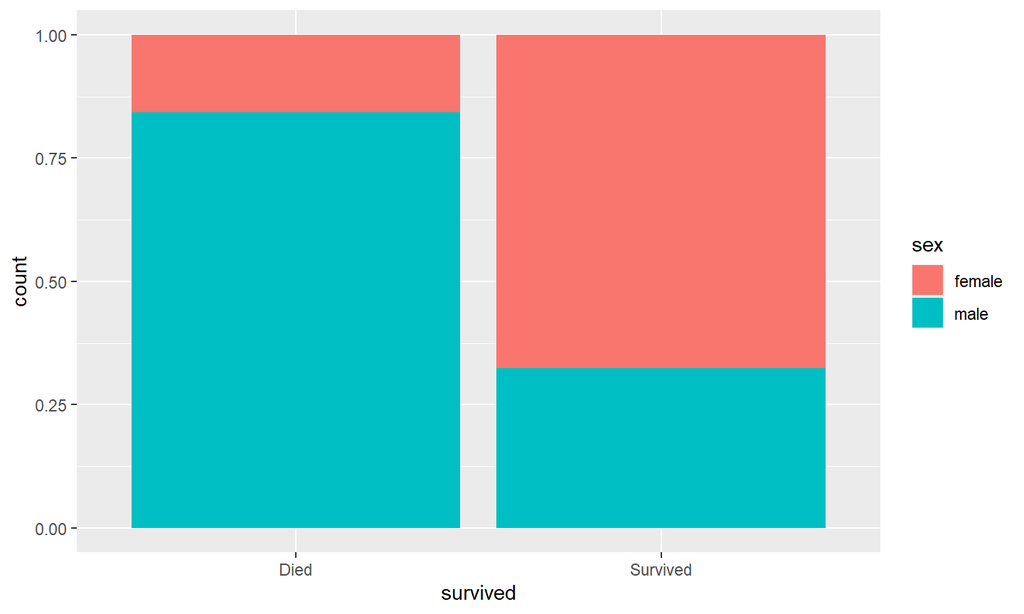

```r
ggplot(data = titanicData, aes(x = survived, fill = sex)) +
  geom_bar(position = "fill")
```

## `ggplot2` faceting

How to create same plot for each `embarked` value? Use **faceting**!

## `ggplot2` faceting

How to create same plot for each `embarked` value? Use **faceting**!

`facet_wrap(~ var)` - creates a plot for each setting of `var`

- Can specify `nrow` and `ncol` or let R figure it out

## `ggplot2` faceting

How to create same plot for each `embarked` value? Use **faceting**!

`facet_wrap(~ var)` - creates a plot for each setting of `var`

- Can specify `nrow` and `ncol` or let R figure it out

`facet_grid(var1 ~ var2)` - creats a plot for each combination of `var1` and `var2`

- `var1` values across rows
- `var2` values across columns
- Use `. ~ var2` or `var1 ~ .` to have only one row or column

## `ggplot2` faceting

How to create same plot for each `embarked` value? Use **faceting**!

- `facet_wrap(~ var)` - creates a plot for each setting of `var`

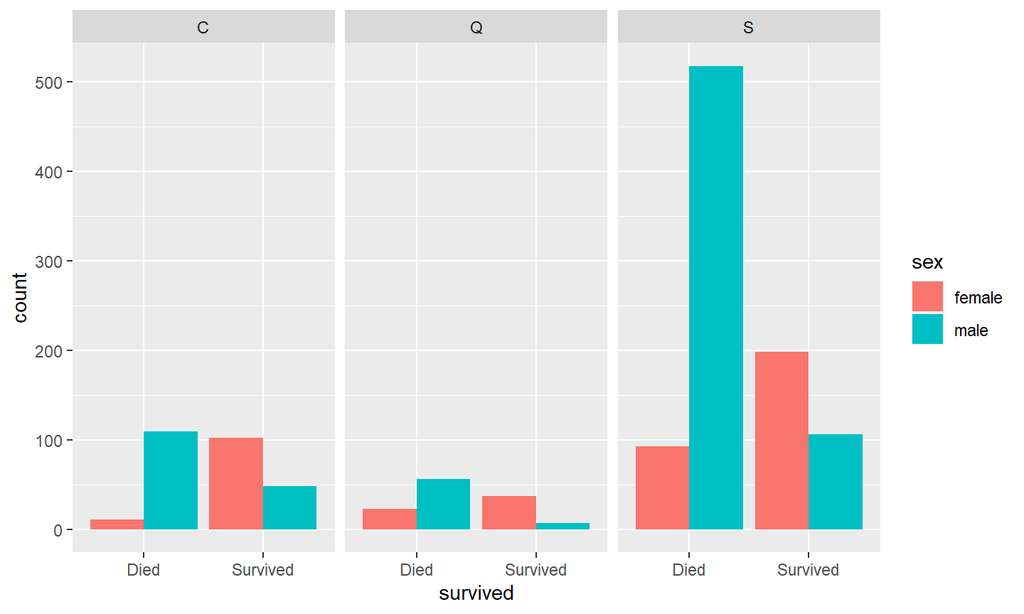

```r
ggplot(data = titanicData, aes(x = survived)) +
  geom_bar(aes(fill =sex), position = "dodge") +
  facet_wrap(~ embarked)
```

## `ggplot2` faceting

How to create same plot for each `pclass` and `embarked` combination?

- `facet_grid(var1 ~ var2)` - creats a plot for each combination of `var1` and `var2`

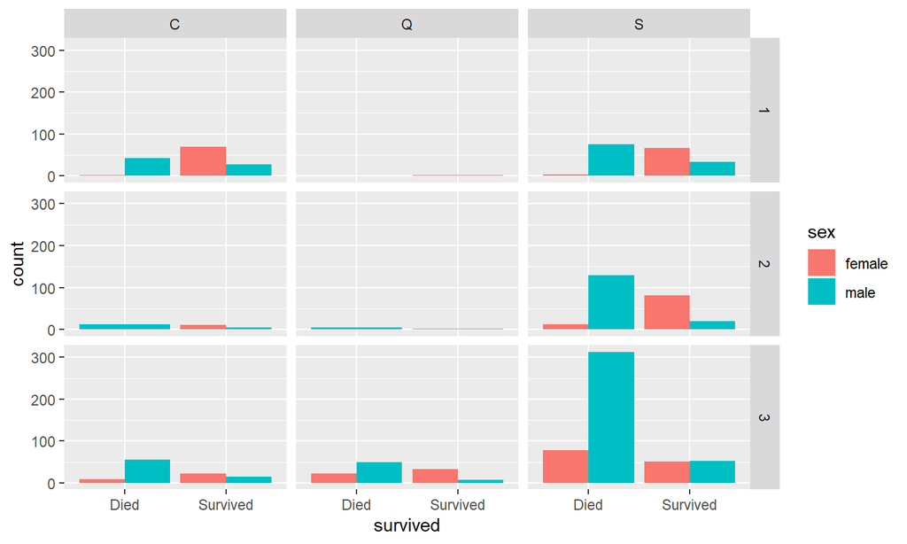

```r
ggplot(data = titanicData, aes(x = survived)) +
  geom_bar(aes(fill =sex), position = "dodge") +
  facet_grid(pclass ~ embarked)
```

## `ggplot2` Plotting: Categorical variables

Recap!

Categorical variable - entries are a label or attribute

- Most common plot is barplot: `ggplot + geom_bar(aes(x = ...))`
- With summary data, use `geom_bar(stat = identity)`
- Stacked barplot via `aes(fill = )`
- Side-by-side barplot via `position = dodge`
- Filled barplot via `position = fill`

## `ggplot2` Plotting Recap

General `ggplot` things:

- Can set local or global `aes`
- Modify titles/labels by adding more layers
- Use either stat or geom layer
- Faceting (multiple plots) via `facet_grid` or `facet_wrap`
- Only need `aes` if setting a mapping value that is dependent on the data (or you want to create a custom legend!)

## `ggplot2` Plotting Recap

General `ggplot` things:

- Can set local or global `aes`
- Modify titles/labels by adding more layers
- Use either stat or geom layer
- Faceting (multiple plots) via `facet_grid` or `facet_wrap`
- Only need `aes` if setting a mapping value that is dependent on the data (or you want to create a custom legend!)

Next: Numeric variable plotting

## `ggplot2` Plotting: Numeric Variables

Numeric variable - entries are a numerical value where math can be performed

Goal: describe the shape, center, and spread

- Generally, via a histogram or boxplot!

Same process:

- Create base object
- Add geoms
- Use aes to specify aspects of the plot

## `ggplot2` Plotting: Numeric Variables

- Look at carbon dioxide (CO2) uptake data set
  - Response recorded: `uptake` CO2 uptake rates in grass plants
  - Environment manipulated: `Treatment` - chilled/nonchilled
  - Ambient CO2 specified and measured: `conc`

```r
CO2 <- as_tibble(CO2)
CO2
```

```
## # A tibble: 84 x 5
##   Plant Type   Treatment   conc uptake
##   <ord> <fct>  <fct>      <dbl>  <dbl>
## 1 Qn1   Quebec nonchilled    95   16
## 2 Qn1   Quebec nonchilled   175   30.4
## 3 Qn1   Quebec nonchilled   250   34.8
## 4 Qn1   Quebec nonchilled   350   37.2
## 5 Qn1   Quebec nonchilled   500   35.3
## # ... with 79 more rows
```

## `ggplot2` histograms

- **Histogram** - Bins data to show distribution of observations
- Common `aes` values (from cheat sheet):

`c + geom_histogram(binwidth = 5)`

`x, y, alpha, color, fill, linetype, size, weight`

- only `x` is really needed

## `ggplot2` histograms

- **Histogram** - Bins data to show distribution of observations

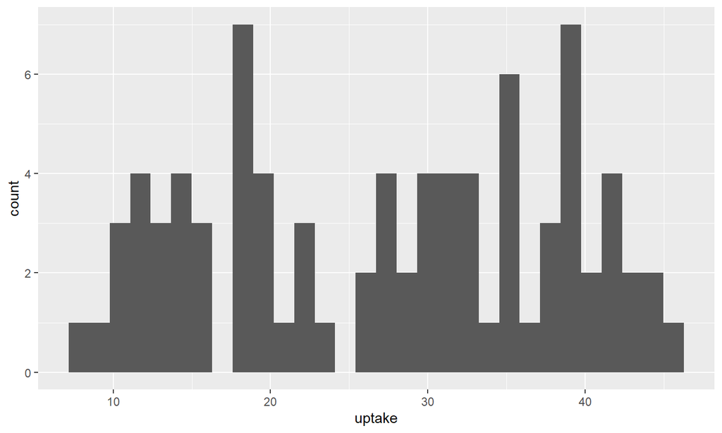

```r
g <- ggplot(CO2, aes(x = uptake))
g + geom_histogram()
```

## `ggplot2` histograms

- **Histogram** - Bins data to show distribution of observations
- Attributes of the plot not dependent on data generally set outside of `aes`

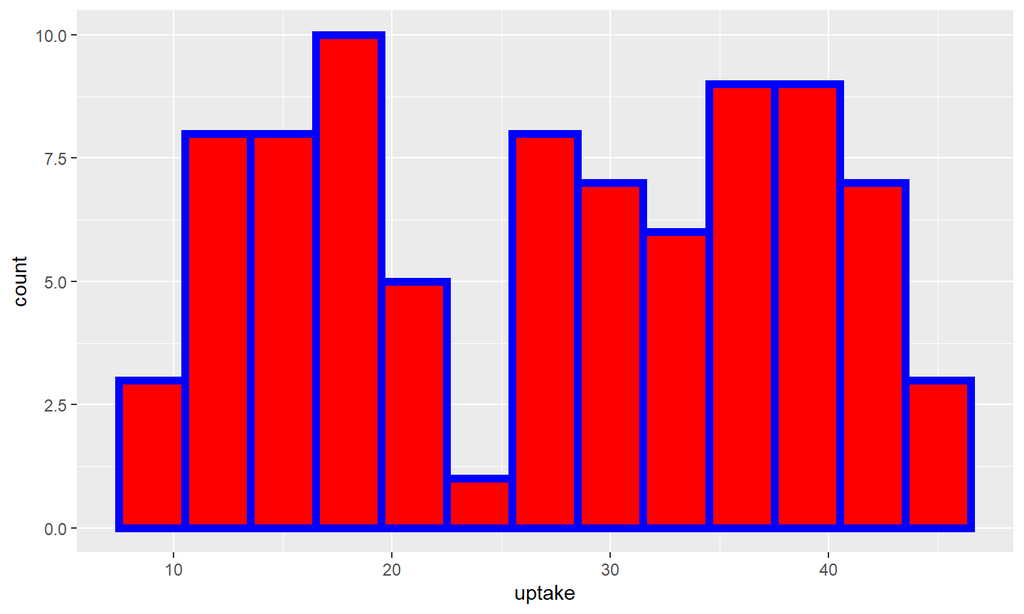

```r
g + geom_histogram(color = "blue", fill = "red", size = 2, binwidth = 3)
```

## `ggplot2` smoothed histogram

- **Kernel Smoother** - Smoothed version of a histogram
- ‘Kernel’ determines weight given to nearby points

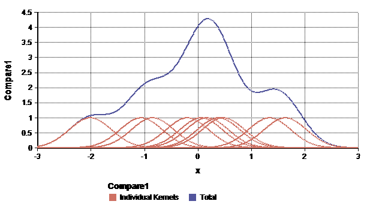

## `ggplot2` smoothed histogram

- **Kernel Smoother** - Smoothed version of a histogram
- Common `aes` values (from cheat sheet):

`c + geom_density(kernel = "gaussian")`

`x, y, alpha, color, fill, group, linetype, size, weight`

- Only `x =` is really needed

## `ggplot2` smoothed histogram

- **Kernel Smoother** - Smoothed version of a histogram

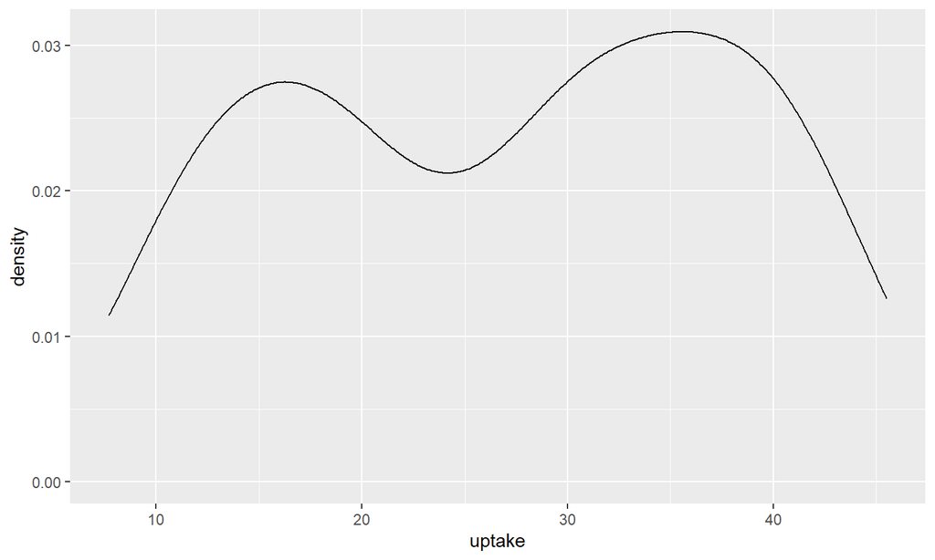

```r
ggplot(CO2, aes(x = uptake)) + geom_density()
```

## `ggplot2` smoothed histogram

- **Kernel Smoother** - Smoothed version of a histogram
- `fill` a useful aesthetic!

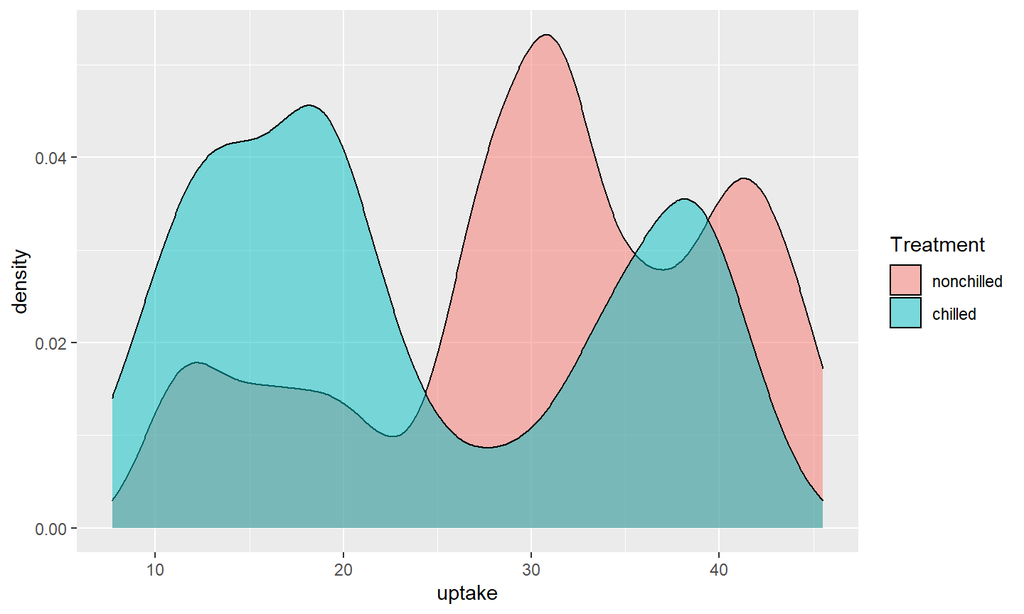

```r
ggplot(CO2, aes(x = uptake)) +
  geom_density(adjust = 0.5, alpha = 0.5, aes(fill = Treatment))
```

## `ggplot2` smoothed histogram

- **Kernel Smoother** - Smoothed version of a histogram
- recall `position` choices of `dodge`, `jitter`, `fill`, and `stack`

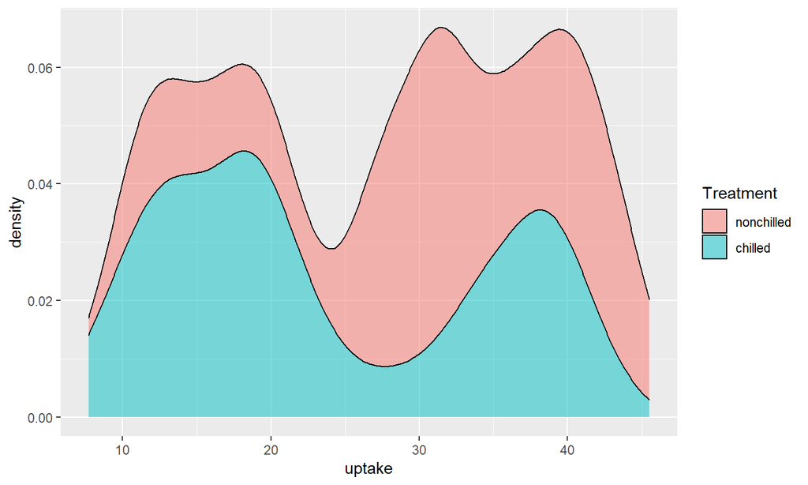

```r
ggplot(CO2, aes(x = uptake)) +
  geom_density(adjust = 0.5, alpha = 0.5, position = "stack", aes(fill = Treatment))
```

## `ggplot2` overlaying plots

- **Histogram + Kernel Smoother**
- Just add both layers! (Works for any compatible layers)
- Use `y = ..density..` to put histogram on same scale

## `ggplot2` overlaying plots

- **Histogram + Kernel Smoother**

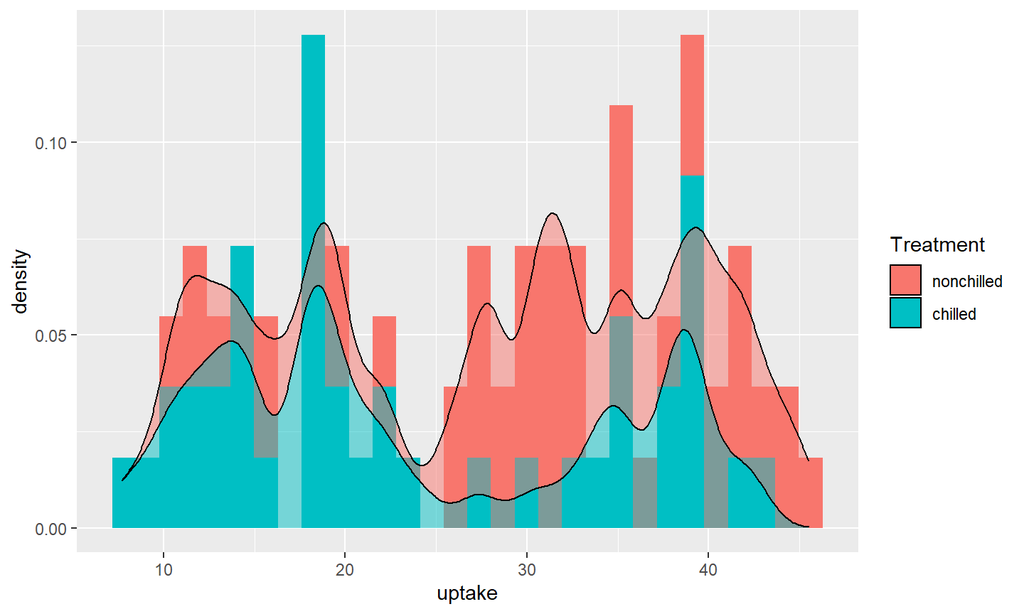

```r
ggplot(CO2) +
  geom_histogram(aes(y = ..density.., x = uptake, fill = Treatment)) +
  geom_density(adjust = 0.25, alpha = 0.5, position = "stack",
               aes(x = uptake, fill = Treatment))
```

## `ggplot2` overlaying plots

- **Histogram + Kernel Smoother**
- Better to set global `aes()` options here!
- Can easily change `fill` variable for all layers

```r
ggplot(CO2, aes(x = uptake, fill = Treatment)) +
  geom_histogram(aes(y = ..density..)) +
  geom_density(adjust = 0.25, alpha = 0.5, position = "stack")
```

## `ggplot2` boxplots

- **Boxplot** - Provides the five number summary in a graph
  - Often used with one numerical and one categorical variable
  - Min, Q1, Median, Q3, Max
  - Often show possible outliers as well

## `ggplot2` boxplots

- **Boxplot** - Provides the five number summary in a graph
- Common `aes` values (from cheat sheet):

`f + geom_boxplot()`

`x, y, lower, middle, upper, ymax, ymin, alpha, color, fill, group, linetype, shape, size, weight`

- Only `x =, y =` are really needed

## `ggplot2` boxplots

- **Boxplot** - Provides the five number summary in a graph

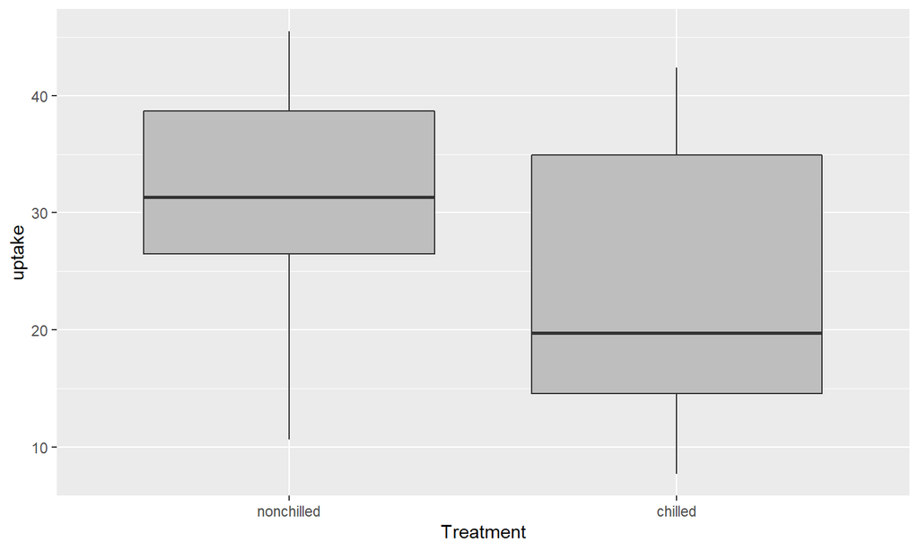

```r
g <- ggplot(CO2, aes(x = Treatment, y = uptake))
g + geom_boxplot(fill = "grey")
```

## `ggplot2` boxplots with points

- **Boxplot** - Provides the five number summary in a graph
- Can add data points (jittered) to see shape of data better

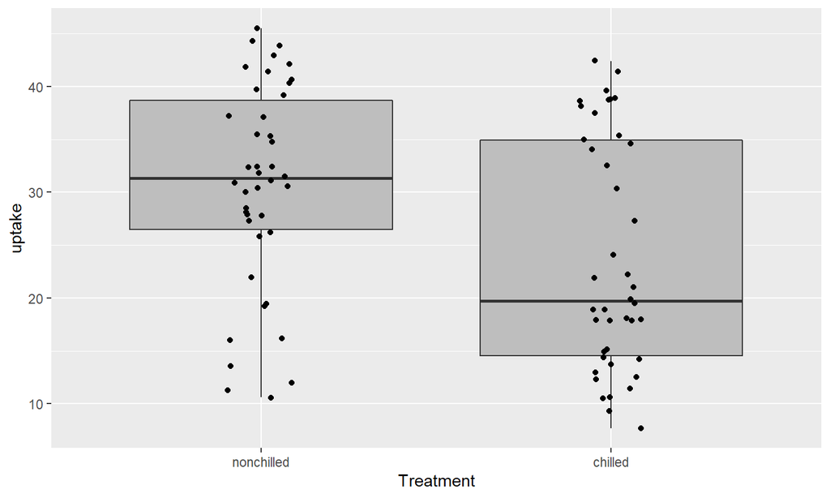

```r
ggplot(CO2, aes(x = Treatment, y = uptake)) +
  geom_boxplot(fill = "grey") +
  geom_jitter(width = 0.1)
```

## `ggplot2` boxplots with points

- **Boxplot** - Provides the five number summary in a graph
- Order of layers important!

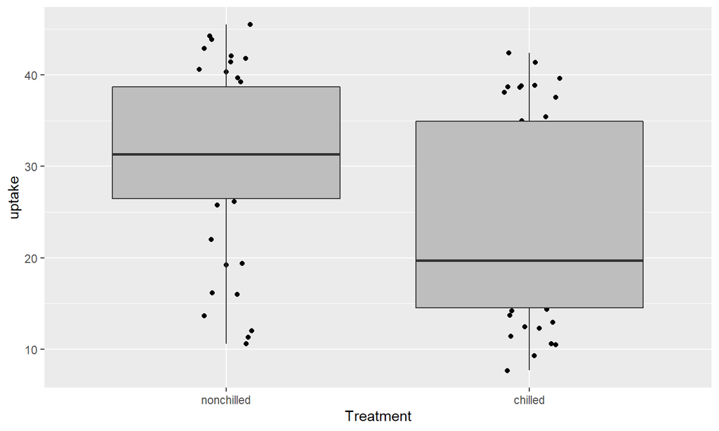

```r
ggplot(CO2, aes(x = Treatment, y = uptake)) +
  geom_jitter(width = 0.1) +
  geom_boxplot(fill = "grey")
```

## `ggplot2` faceting

- **Boxplot** - Provides the five number summary in a graph
- Can `facet` easily!

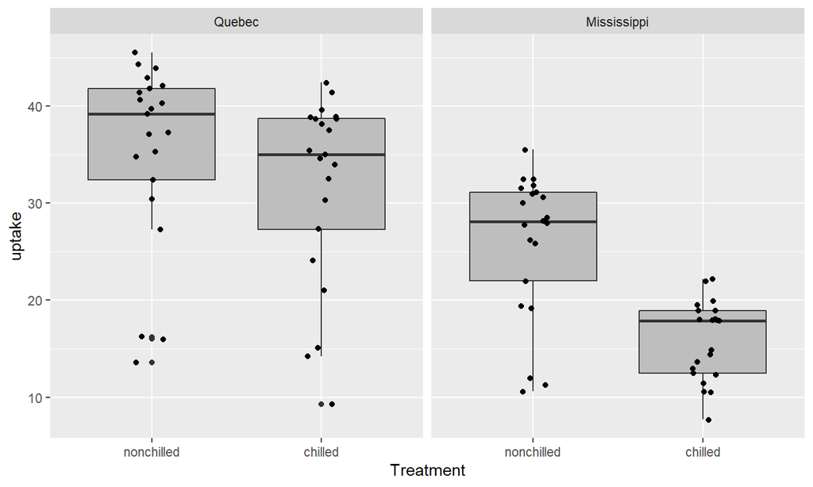

```r
ggplot(CO2, aes(x = Treatment, y = uptake)) + geom_boxplot(fill = "grey") +
  geom_jitter(width = 0.1) + facet_wrap(~ Type)
```

## `ggplot2` scatter plots

Two numerical variables

- **Scatter Plot** - graphs points corresponding to each observation
- Common `aes` values (from cheat sheet):

`e + geom_point()`

`x, y, alpha, color, fill, shape, size, stroke`

- Only `x =, y =` are really needed

## `ggplot2` scatter plots

- **Scatter Plot** - graphs points corresponding to each observation

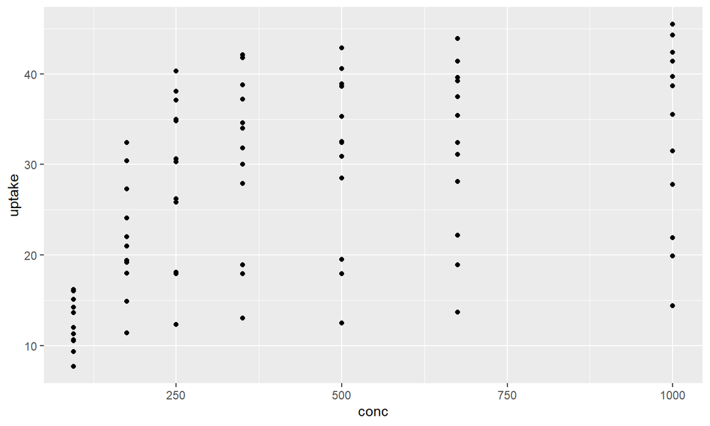

```r
g <- ggplot(CO2, aes(x = conc, y = uptake))
g + geom_point()
```

## `ggplot2` scatter plots with trend line

- Add trend lines easily (linear and loess - a smoother)

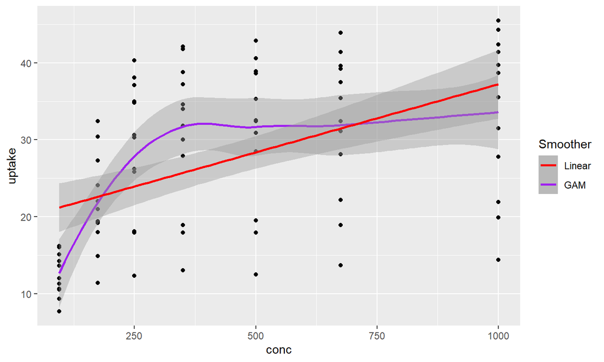

```r
ggplot(CO2, aes(x = conc, y = uptake)) + geom_point() +
  geom_smooth(aes(col = "loess")) +
  geom_smooth(method = lm, aes(col = "linear")) +
  scale_colour_manual(name = 'Smoother', values =c('linear'='red', 'loess'='purple'),
                      labels = c('Linear','GAM'), guide = 'legend')
```

## `ggplot2` scatter plots with text

- May want to add value of correlation to plot
- `paste()` or `paste0()` handy

```r
paste("Hi", "What", "Is", "Going", "On", "?", sep = " ")
```

```
## [1] "Hi What Is Going On ?"
```

```r
paste("Hi", "What", "Is", "Going", "On", "?", sep = ".")
```

```
## [1] "Hi.What.Is.Going.On.?"
```

```r
paste0("Hi", "What", "Is", "Going", "On", "?")
```

```
## [1] "HiWhatIsGoingOn?"
```

## `ggplot2` scatter plots with text

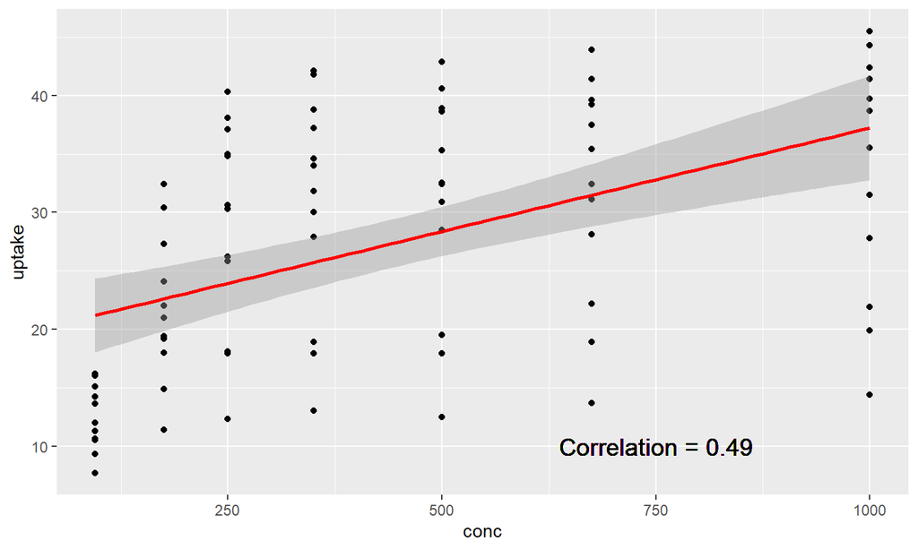

```r
correlation <- cor(CO2$conc, CO2$uptake)
ggplot(CO2, aes(x = conc, y = uptake)) + geom_point() +
  geom_smooth(method = lm, col = "Red") +
  geom_text(x = 750, y = 10, size = 5,
            label = paste0("Correlation = ", round(correlation, 2)))
```

## `ggplot2` scatter plots with text points

- Text for points with `geom_text`

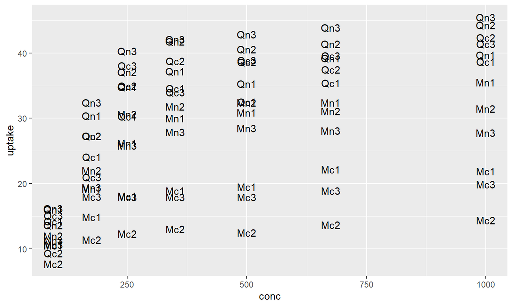

```r
ggplot(CO2, aes(x = conc, y = uptake)) +
  geom_text(aes(label = Plant))
```

## `ggplot2` faceting

- Easily facet! (Note: `cut()` is useful for categorizing a numeric variable)

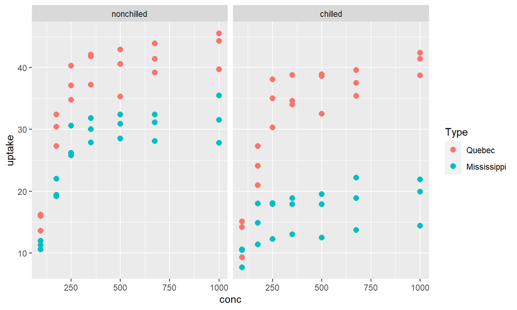

```r
ggplot(CO2, aes(x = conc, y = uptake)) +
  geom_point(aes(color = Type), size = 2.5) +
  facet_wrap(~ Treatment)
```

## `ggpairs`

- Saw `pairs`, better with `GGally::ggpairs()`

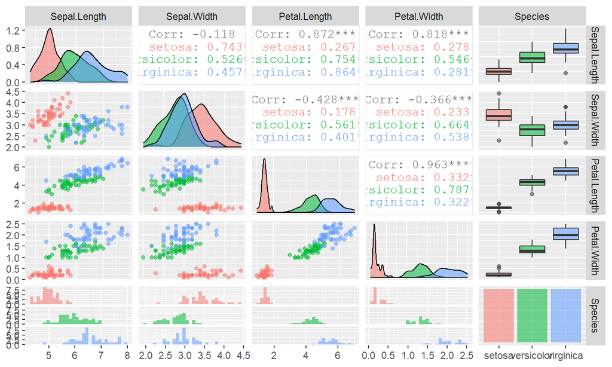

```r
library(GGally) #install GGally if needed
ggpairs(iris, aes(colour = Species, alpha = 0.4))
```

## `ggplot2` Plotting: Numeric variables

Recap!

Numeric variable - entries are a numerical value where math can be performed

Most common plots:

## `ggplot2` Plotting Recap

General `ggplot` things:

- Can set local or global `aes`
- Modify titles/labels by adding more layers
- Use either stat or geom layer
- Faceting (multiple plots) via `facet_grid` or `facet_wrap`
- Only need `aes` if setting a mapping value that is dependent on the data (or you want to create a custom legend!)

## Recap!

`ggplot(data = <DATA>) +`  
`<GEOM_FUNCTION>(mapping = aes(<MAPPINGS>), stat = <STAT>, position = <POSITION>) +`  
`<COORDINATE_FUNCTION> +`  
`<FACET_FUNCTION> +`  
`<LABEL_FUNCTION>`  
`)`

- Lots of extensions to ggplot!
  - `gganimate`
  - `ggthemes`
  - `ggmap`
  - `ggrepel`